# 결과: 회분 3-2.sas

The TRANSREG Procedure

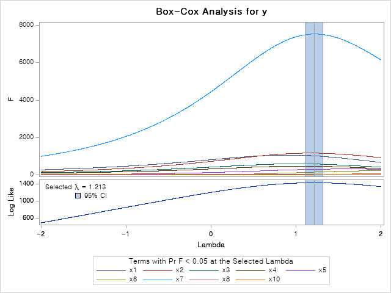

The REG Procedure

Model: MODEL1

Dependent Variable: sy

| Number of Observations Read | 792 |
| --- | --- |
| Number of Observations Used | 792 |

| Analysis of Variance Source | Analysis of Variance DF | Analysis of Variance Sum of Squares | Analysis of Variance Mean Square | Analysis of Variance F Value | Analysis of Variance Pr > F |
| --- | --- | --- | --- | --- | --- |
| Model | 1 | 1770.41518 | 1770.41518 | 1321.70 | <.0001 |
| Error | 790 | 1058.20707 | 1.33950 |  |  |
| Corrected Total | 791 | 2828.62224 |  |  |  |

| Root MSE | 1.15737 | R-Square | 0.6259 |
| --- | --- | --- | --- |
| Dependent Mean | 7.72892 | Adj R-Sq | 0.6254 |
| Coeff Var | 14.97453 |  |  |

| Parameter Estimates Variable | Parameter Estimates DF | Parameter Estimates Parameter Estimate | Parameter Estimates Standard Error | Parameter Estimates t Value | Parameter Estimates Pr > \|t\| |
| --- | --- | --- | --- | --- | --- |
| Intercept | 1 | 4.12355 | 0.10736 | 38.41 | <.0001 |
| v1 | 1 | 3.88006 | 0.10673 | 36.36 | <.0001 |

The REG Procedure

Model: MODEL1

Dependent Variable: sy

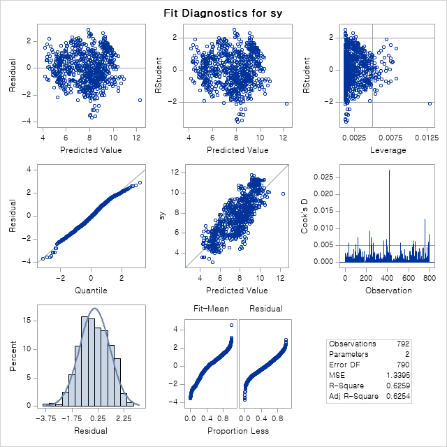

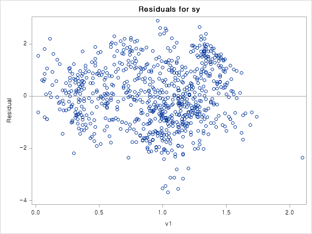

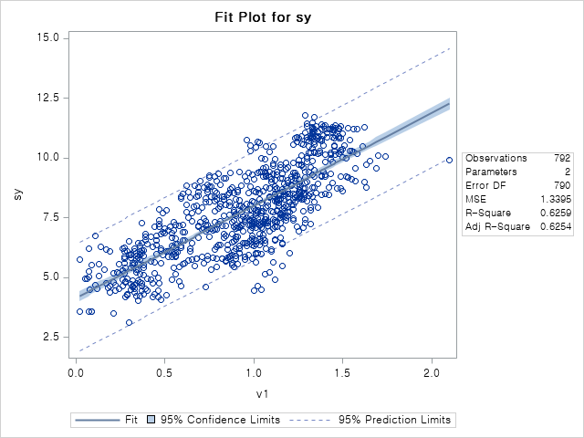

The REG Procedure

Model: MODEL2

Dependent Variable: sy

| Number of Observations Read | 792 |
| --- | --- |
| Number of Observations Used | 792 |

| Analysis of Variance Source | Analysis of Variance DF | Analysis of Variance Sum of Squares | Analysis of Variance Mean Square | Analysis of Variance F Value | Analysis of Variance Pr > F |
| --- | --- | --- | --- | --- | --- |
| Model | 2 | 1782.69146 | 891.34573 | 672.39 | <.0001 |
| Error | 789 | 1045.93079 | 1.32564 |  |  |
| Corrected Total | 791 | 2828.62224 |  |  |  |

| Root MSE | 1.15136 | R-Square | 0.6302 |
| --- | --- | --- | --- |
| Dependent Mean | 7.72892 | Adj R-Sq | 0.6293 |
| Coeff Var | 14.89684 |  |  |

| Parameter Estimates Variable | Parameter Estimates DF | Parameter Estimates Parameter Estimate | Parameter Estimates Standard Error | Parameter Estimates t Value | Parameter Estimates Pr > \|t\| |
| --- | --- | --- | --- | --- | --- |
| Intercept | 1 | 4.88874 | 0.27319 | 17.89 | <.0001 |
| v1 | 1 | 3.02683 | 0.29981 | 10.10 | <.0001 |
| vlnv1 | 1 | 1.13164 | 0.37187 | 3.04 | 0.0024 |

The REG Procedure

Model: MODEL2

Dependent Variable: sy

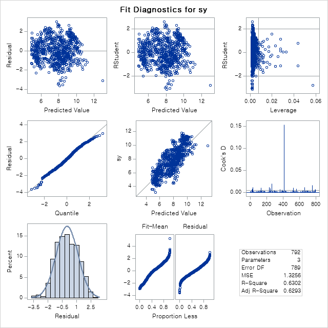

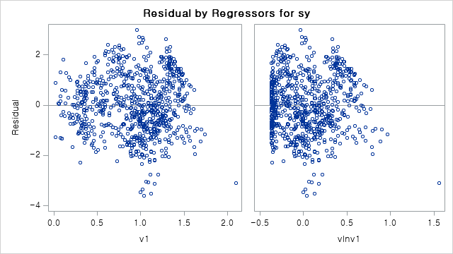

The REG Procedure

Model: MODEL1

Dependent Variable: sy

| Number of Observations Read | 792 |
| --- | --- |
| Number of Observations Used | 792 |

| Analysis of Variance Source | Analysis of Variance DF | Analysis of Variance Sum of Squares | Analysis of Variance Mean Square | Analysis of Variance F Value | Analysis of Variance Pr > F |
| --- | --- | --- | --- | --- | --- |
| Model | 1 | 1283.87194 | 1283.87194 | 656.58 | <.0001 |
| Error | 790 | 1544.75030 | 1.95538 |  |  |
| Corrected Total | 791 | 2828.62224 |  |  |  |

| Root MSE | 1.39835 | R-Square | 0.4539 |
| --- | --- | --- | --- |
| Dependent Mean | 7.72892 | Adj R-Sq | 0.4532 |
| Coeff Var | 18.09243 |  |  |

| Parameter Estimates Variable | Parameter Estimates DF | Parameter Estimates Parameter Estimate | Parameter Estimates Standard Error | Parameter Estimates t Value | Parameter Estimates Pr > \|t\| |
| --- | --- | --- | --- | --- | --- |
| Intercept | 1 | 3.30790 | 0.17955 | 18.42 | <.0001 |
| v2 | 1 | 4.37451 | 0.17072 | 25.62 | <.0001 |

The REG Procedure

Model: MODEL1

Dependent Variable: sy

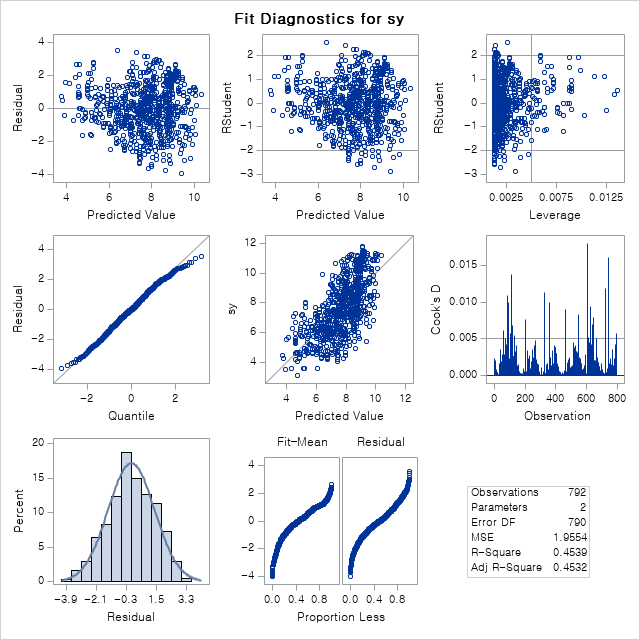

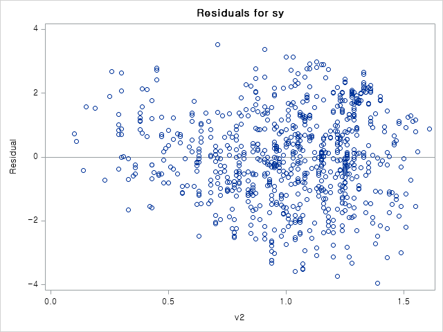

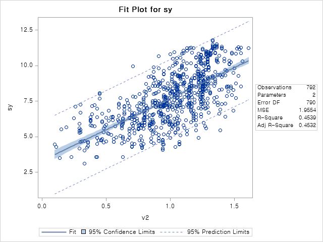

The REG Procedure

Model: MODEL2

Dependent Variable: sy

| Number of Observations Read | 792 |
| --- | --- |
| Number of Observations Used | 792 |

| Analysis of Variance Source | Analysis of Variance DF | Analysis of Variance Sum of Squares | Analysis of Variance Mean Square | Analysis of Variance F Value | Analysis of Variance Pr > F |
| --- | --- | --- | --- | --- | --- |
| Model | 2 | 1314.87336 | 657.43668 | 342.67 | <.0001 |
| Error | 789 | 1513.74888 | 1.91857 |  |  |
| Corrected Total | 791 | 2828.62224 |  |  |  |

| Root MSE | 1.38512 | R-Square | 0.4648 |
| --- | --- | --- | --- |
| Dependent Mean | 7.72892 | Adj R-Sq | 0.4635 |
| Coeff Var | 17.92131 |  |  |

| Parameter Estimates Variable | Parameter Estimates DF | Parameter Estimates Parameter Estimate | Parameter Estimates Standard Error | Parameter Estimates t Value | Parameter Estimates Pr > \|t\| |
| --- | --- | --- | --- | --- | --- |
| Intercept | 1 | 5.65563 | 0.61052 | 9.26 | <.0001 |
| v2 | 1 | 1.88352 | 0.64234 | 2.93 | 0.0035 |
| vlnv2 | 1 | 2.92014 | 0.72644 | 4.02 | <.0001 |

The REG Procedure

Model: MODEL2

Dependent Variable: sy

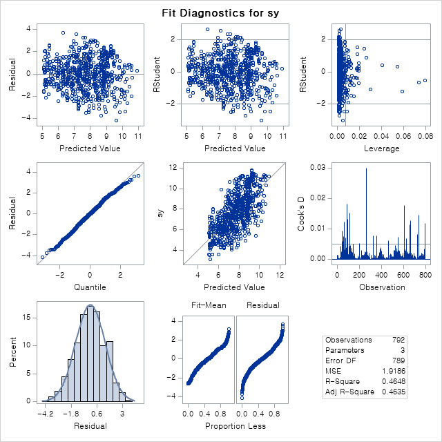

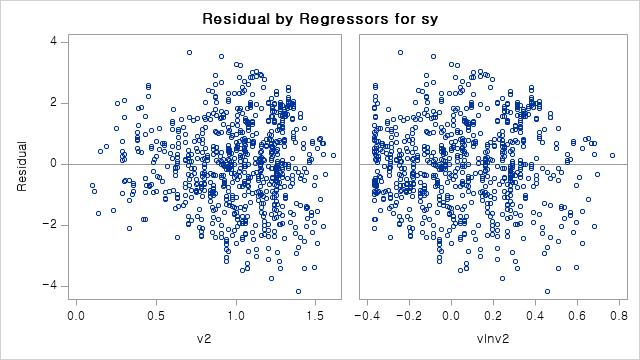

The REG Procedure

Model: MODEL1

Dependent Variable: sy

| Number of Observations Read | 792 |
| --- | --- |
| Number of Observations Used | 792 |

| Analysis of Variance Source | Analysis of Variance DF | Analysis of Variance Sum of Squares | Analysis of Variance Mean Square | Analysis of Variance F Value | Analysis of Variance Pr > F |
| --- | --- | --- | --- | --- | --- |
| Model | 1 | 1611.27655 | 1611.27655 | 1045.64 | <.0001 |
| Error | 790 | 1217.34570 | 1.54094 |  |  |
| Corrected Total | 791 | 2828.62224 |  |  |  |

| Root MSE | 1.24135 | R-Square | 0.5696 |
| --- | --- | --- | --- |
| Dependent Mean | 7.72892 | Adj R-Sq | 0.5691 |
| Coeff Var | 16.06108 |  |  |

| Parameter Estimates Variable | Parameter Estimates DF | Parameter Estimates Parameter Estimate | Parameter Estimates Standard Error | Parameter Estimates t Value | Parameter Estimates Pr > \|t\| |
| --- | --- | --- | --- | --- | --- |
| Intercept | 1 | 3.71423 | 0.13176 | 28.19 | <.0001 |
| v3 | 1 | 6.18161 | 0.19117 | 32.34 | <.0001 |

The REG Procedure

Model: MODEL1

Dependent Variable: sy

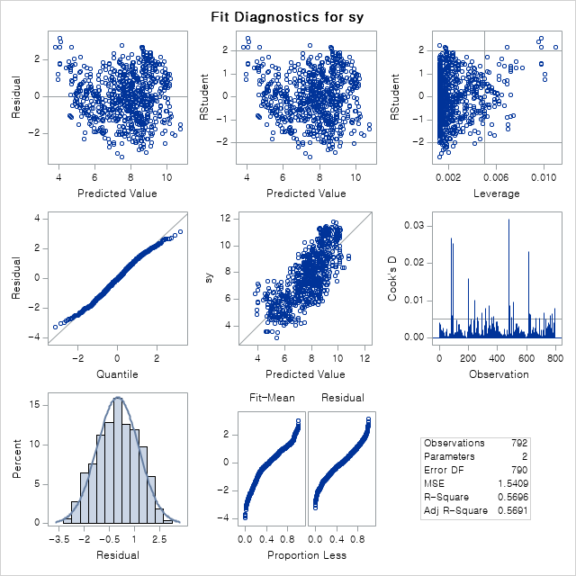

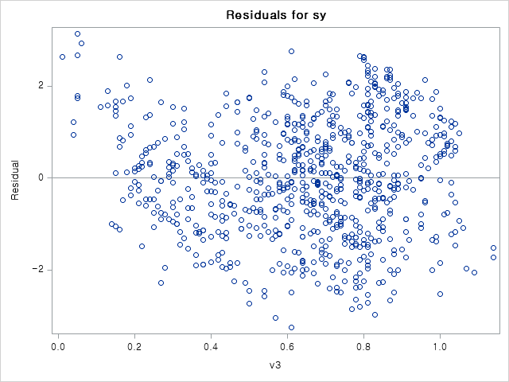

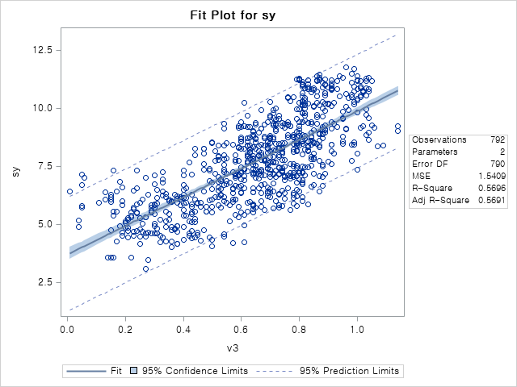

The REG Procedure

Model: MODEL2

Dependent Variable: sy

| Number of Observations Read | 792 |
| --- | --- |
| Number of Observations Used | 792 |

| Analysis of Variance Source | Analysis of Variance DF | Analysis of Variance Sum of Squares | Analysis of Variance Mean Square | Analysis of Variance F Value | Analysis of Variance Pr > F |
| --- | --- | --- | --- | --- | --- |
| Model | 2 | 1664.64862 | 832.32431 | 564.19 | <.0001 |
| Error | 789 | 1163.97362 | 1.47525 |  |  |
| Corrected Total | 791 | 2828.62224 |  |  |  |

| Root MSE | 1.21460 | R-Square | 0.5885 |
| --- | --- | --- | --- |
| Dependent Mean | 7.72892 | Adj R-Sq | 0.5875 |
| Coeff Var | 15.71500 |  |  |

| Parameter Estimates Variable | Parameter Estimates DF | Parameter Estimates Parameter Estimate | Parameter Estimates Standard Error | Parameter Estimates t Value | Parameter Estimates Pr > \|t\| |
| --- | --- | --- | --- | --- | --- |
| Intercept | 1 | 5.74314 | 0.36111 | 15.90 | <.0001 |
| v3 | 1 | 4.54865 | 0.32969 | 13.80 | <.0001 |
| vlnv3 | 1 | 4.15689 | 0.69111 | 6.01 | <.0001 |

The REG Procedure

Model: MODEL2

Dependent Variable: sy

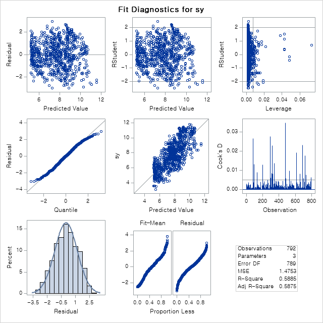

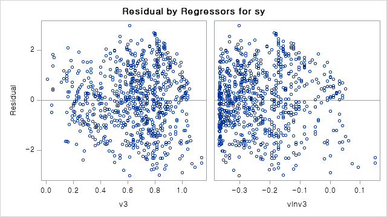

The REG Procedure

Model: MODEL1

Dependent Variable: sy

| Number of Observations Read | 792 |
| --- | --- |
| Number of Observations Used | 792 |

| Analysis of Variance Source | Analysis of Variance DF | Analysis of Variance Sum of Squares | Analysis of Variance Mean Square | Analysis of Variance F Value | Analysis of Variance Pr > F |
| --- | --- | --- | --- | --- | --- |
| Model | 1 | 842.79930 | 842.79930 | 335.28 | <.0001 |
| Error | 790 | 1985.82295 | 2.51370 |  |  |
| Corrected Total | 791 | 2828.62224 |  |  |  |

| Root MSE | 1.58547 | R-Square | 0.2980 |
| --- | --- | --- | --- |
| Dependent Mean | 7.72892 | Adj R-Sq | 0.2971 |
| Coeff Var | 20.51342 |  |  |

| Parameter Estimates Variable | Parameter Estimates DF | Parameter Estimates Parameter Estimate | Parameter Estimates Standard Error | Parameter Estimates t Value | Parameter Estimates Pr > \|t\| |
| --- | --- | --- | --- | --- | --- |
| Intercept | 1 | 4.70915 | 0.17428 | 27.02 | <.0001 |
| v4 | 1 | 7.05774 | 0.38544 | 18.31 | <.0001 |

The REG Procedure

Model: MODEL1

Dependent Variable: sy

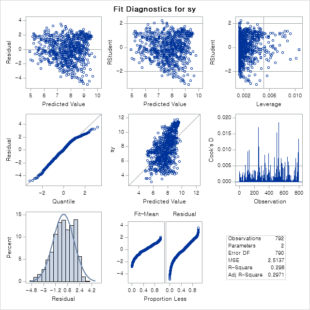

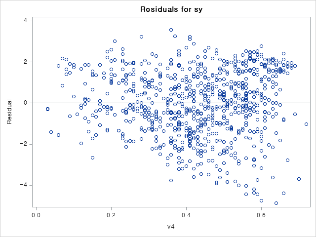

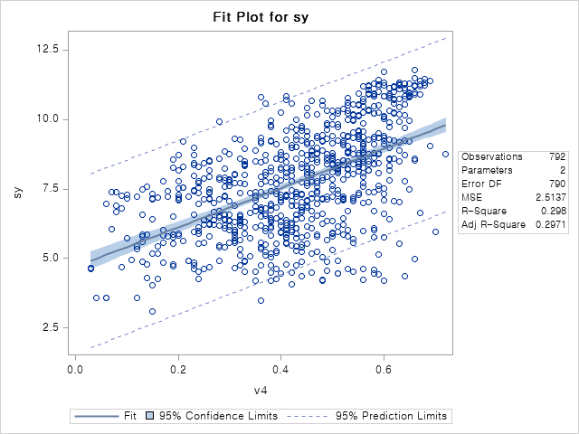

The REG Procedure

Model: MODEL2

Dependent Variable: sy

| Number of Observations Read | 792 |
| --- | --- |
| Number of Observations Used | 792 |

| Analysis of Variance Source | Analysis of Variance DF | Analysis of Variance Sum of Squares | Analysis of Variance Mean Square | Analysis of Variance F Value | Analysis of Variance Pr > F |
| --- | --- | --- | --- | --- | --- |
| Model | 2 | 884.24130 | 442.12065 | 179.41 | <.0001 |
| Error | 789 | 1944.38094 | 2.46436 |  |  |
| Corrected Total | 791 | 2828.62224 |  |  |  |

| Root MSE | 1.56983 | R-Square | 0.3126 |
| --- | --- | --- | --- |
| Dependent Mean | 7.72892 | Adj R-Sq | 0.3109 |
| Coeff Var | 20.31110 |  |  |

| Parameter Estimates Variable | Parameter Estimates DF | Parameter Estimates Parameter Estimate | Parameter Estimates Standard Error | Parameter Estimates t Value | Parameter Estimates Pr > \|t\| |
| --- | --- | --- | --- | --- | --- |
| Intercept | 1 | 6.74794 | 0.52626 | 12.82 | <.0001 |
| v4 | 1 | 7.05506 | 0.38164 | 18.49 | <.0001 |
| vlnv4 | 1 | 6.08350 | 1.48349 | 4.10 | <.0001 |

The REG Procedure

Model: MODEL2

Dependent Variable: sy

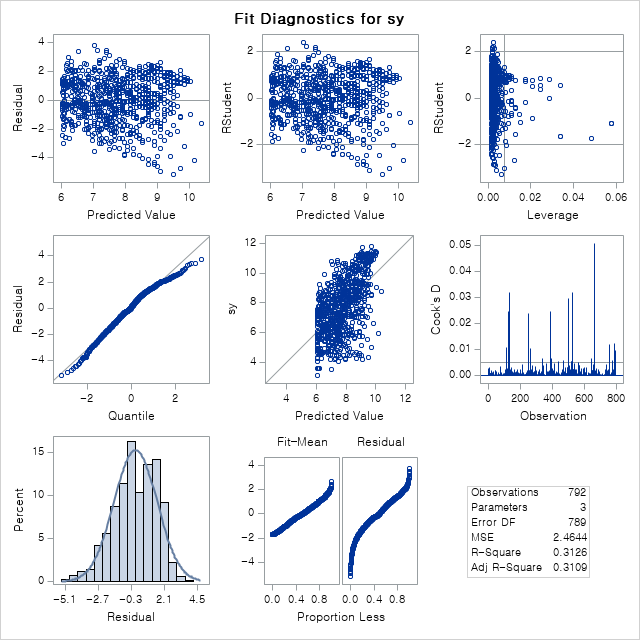

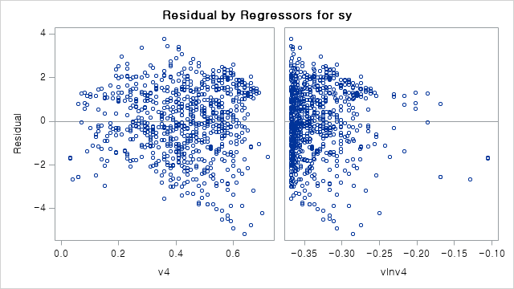

The REG Procedure

Model: MODEL1

Dependent Variable: sy

| Number of Observations Read | 792 |
| --- | --- |
| Number of Observations Used | 791 |
| Number of Observations with Missing Values | 1 |

| Analysis of Variance Source | Analysis of Variance DF | Analysis of Variance Sum of Squares | Analysis of Variance Mean Square | Analysis of Variance F Value | Analysis of Variance Pr > F |
| --- | --- | --- | --- | --- | --- |
| Model | 1 | 73.27329 | 73.27329 | 20.98 | <.0001 |
| Error | 789 | 2755.20561 | 3.49202 |  |  |
| Corrected Total | 790 | 2828.47890 |  |  |  |

| Root MSE | 1.86870 | R-Square | 0.0259 |
| --- | --- | --- | --- |
| Dependent Mean | 7.72844 | Adj R-Sq | 0.0247 |
| Coeff Var | 24.17946 |  |  |

| Parameter Estimates Variable | Parameter Estimates DF | Parameter Estimates Parameter Estimate | Parameter Estimates Standard Error | Parameter Estimates t Value | Parameter Estimates Pr > \|t\| |
| --- | --- | --- | --- | --- | --- |
| Intercept | 1 | 7.18488 | 0.13600 | 52.83 | <.0001 |
| v5 | 1 | 2.53632 | 0.55369 | 4.58 | <.0001 |

The REG Procedure

Model: MODEL1

Dependent Variable: sy

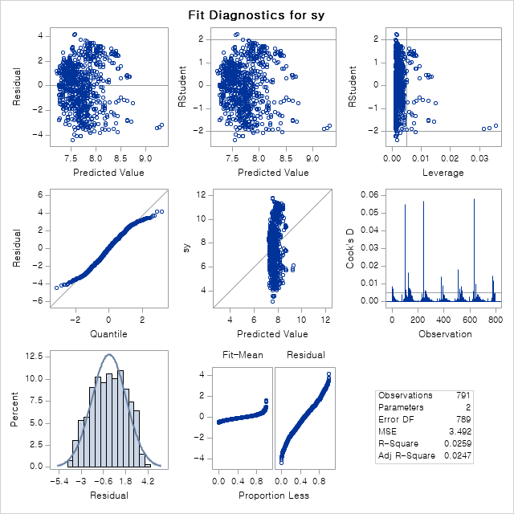

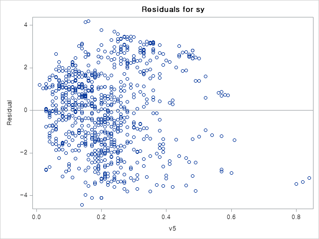

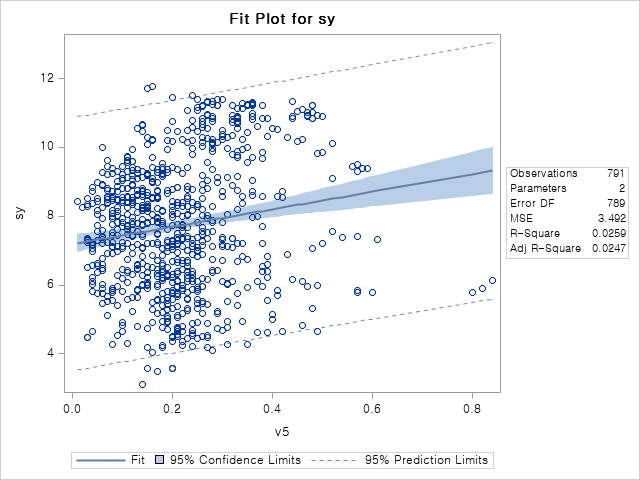

The REG Procedure

Model: MODEL2

Dependent Variable: sy

| Number of Observations Read | 792 |
| --- | --- |
| Number of Observations Used | 791 |
| Number of Observations with Missing Values | 1 |

| Analysis of Variance Source | Analysis of Variance DF | Analysis of Variance Sum of Squares | Analysis of Variance Mean Square | Analysis of Variance F Value | Analysis of Variance Pr > F |
| --- | --- | --- | --- | --- | --- |
| Model | 2 | 73.96143 | 36.98071 | 10.58 | <.0001 |
| Error | 788 | 2754.51748 | 3.49558 |  |  |
| Corrected Total | 790 | 2828.47890 |  |  |  |

| Root MSE | 1.86965 | R-Square | 0.0261 |
| --- | --- | --- | --- |
| Dependent Mean | 7.72844 | Adj R-Sq | 0.0237 |
| Coeff Var | 24.19178 |  |  |

| Parameter Estimates Variable | Parameter Estimates DF | Parameter Estimates Parameter Estimate | Parameter Estimates Standard Error | Parameter Estimates t Value | Parameter Estimates Pr > \|t\| |
| --- | --- | --- | --- | --- | --- |
| Intercept | 1 | 7.05010 | 0.33286 | 21.18 | <.0001 |
| v5 | 1 | 2.28195 | 0.79721 | 2.86 | 0.0043 |
| vlnv5 | 1 | -0.63542 | 1.43213 | -0.44 | 0.6574 |

The REG Procedure

Model: MODEL2

Dependent Variable: sy

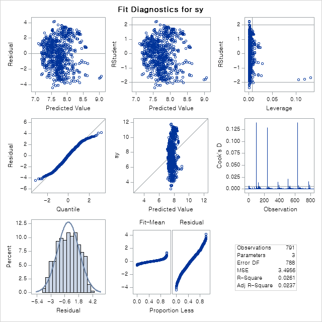

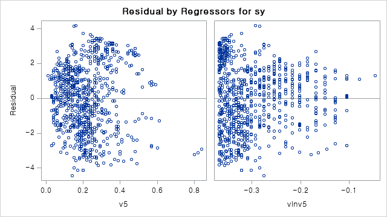

The REG Procedure

Model: MODEL1

Dependent Variable: y

| Number of Observations Read | 792 |
| --- | --- |
| Number of Observations Used | 780 |
| Number of Observations with Missing Values | 12 |

| Analysis of Variance Source | Analysis of Variance DF | Analysis of Variance Sum of Squares | Analysis of Variance Mean Square | Analysis of Variance F Value | Analysis of Variance Pr > F |
| --- | --- | --- | --- | --- | --- |
| Model | 1 | 207.69819 | 207.69819 | 206.54 | <.0001 |
| Error | 778 | 782.34993 | 1.00559 |  |  |
| Corrected Total | 779 | 990.04811 |  |  |  |

| Root MSE | 1.00279 | R-Square | 0.2098 |
| --- | --- | --- | --- |
| Dependent Mean | 5.47682 | Adj R-Sq | 0.2088 |
| Coeff Var | 18.30974 |  |  |

| Parameter Estimates Variable | Parameter Estimates DF | Parameter Estimates Parameter Estimate | Parameter Estimates Standard Error | Parameter Estimates t Value | Parameter Estimates Pr > \|t\| |
| --- | --- | --- | --- | --- | --- |
| Intercept | 1 | 4.86989 | 0.05543 | 87.85 | <.0001 |
| v6 | 1 | 4.75210 | 0.33066 | 14.37 | <.0001 |

The REG Procedure

Model: MODEL1

Dependent Variable: y

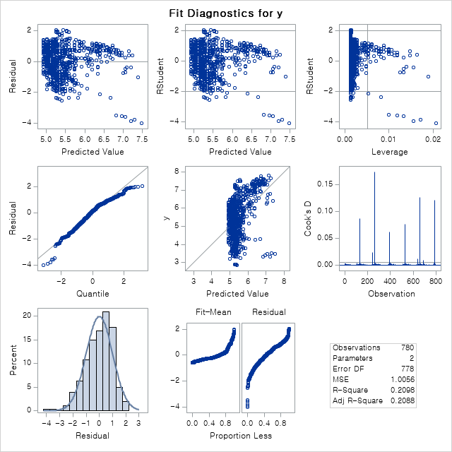

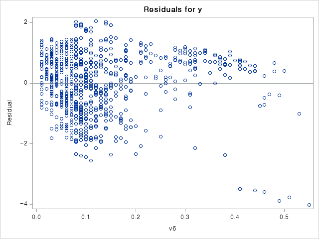

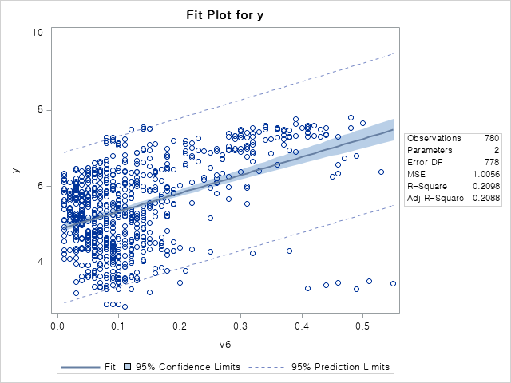

The REG Procedure

Model: MODEL2

Dependent Variable: y

| Number of Observations Read | 792 |
| --- | --- |
| Number of Observations Used | 780 |
| Number of Observations with Missing Values | 12 |

| Analysis of Variance Source | Analysis of Variance DF | Analysis of Variance Sum of Squares | Analysis of Variance Mean Square | Analysis of Variance F Value | Analysis of Variance Pr > F |
| --- | --- | --- | --- | --- | --- |
| Model | 2 | 210.59863 | 105.29932 | 104.97 | <.0001 |
| Error | 777 | 779.44948 | 1.00315 |  |  |
| Corrected Total | 779 | 990.04811 |  |  |  |

| Root MSE | 1.00158 | R-Square | 0.2127 |
| --- | --- | --- | --- |
| Dependent Mean | 5.47682 | Adj R-Sq | 0.2107 |
| Coeff Var | 18.28753 |  |  |

| Parameter Estimates Variable | Parameter Estimates DF | Parameter Estimates Parameter Estimate | Parameter Estimates Standard Error | Parameter Estimates t Value | Parameter Estimates Pr > \|t\| |
| --- | --- | --- | --- | --- | --- |
| Intercept | 1 | 5.06309 | 0.12639 | 40.06 | <.0001 |
| v6 | 1 | 5.80692 | 0.70278 | 8.26 | <.0001 |
| vlnv6 | 1 | 1.46768 | 0.86314 | 1.70 | 0.0895 |

The REG Procedure

Model: MODEL2

Dependent Variable: y

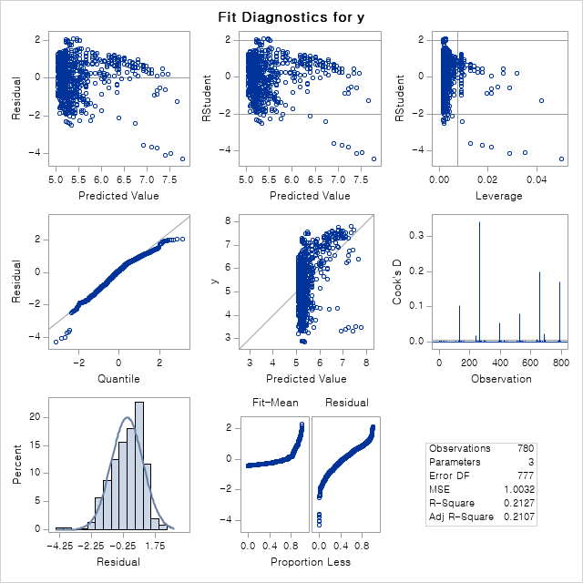

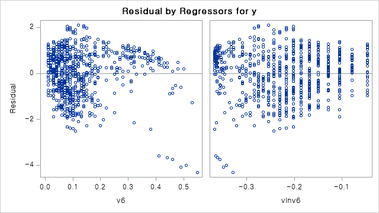

The REG Procedure

Model: MODEL1

Dependent Variable: sy

| Number of Observations Read | 792 |
| --- | --- |
| Number of Observations Used | 792 |

| Analysis of Variance Source | Analysis of Variance DF | Analysis of Variance Sum of Squares | Analysis of Variance Mean Square | Analysis of Variance F Value | Analysis of Variance Pr > F |
| --- | --- | --- | --- | --- | --- |
| Model | 1 | 765.98176 | 765.98176 | 293.37 | <.0001 |
| Error | 790 | 2062.64049 | 2.61094 |  |  |
| Corrected Total | 791 | 2828.62224 |  |  |  |

| Root MSE | 1.61584 | R-Square | 0.2708 |
| --- | --- | --- | --- |
| Dependent Mean | 7.72892 | Adj R-Sq | 0.2699 |
| Coeff Var | 20.90641 |  |  |

| Parameter Estimates Variable | Parameter Estimates DF | Parameter Estimates Parameter Estimate | Parameter Estimates Standard Error | Parameter Estimates t Value | Parameter Estimates Pr > \|t\| |
| --- | --- | --- | --- | --- | --- |
| Intercept | 1 | 3.85881 | 0.23313 | 16.55 | <.0001 |
| v7 | 1 | 1.87051 | 0.10921 | 17.13 | <.0001 |

The REG Procedure

Model: MODEL1

Dependent Variable: sy

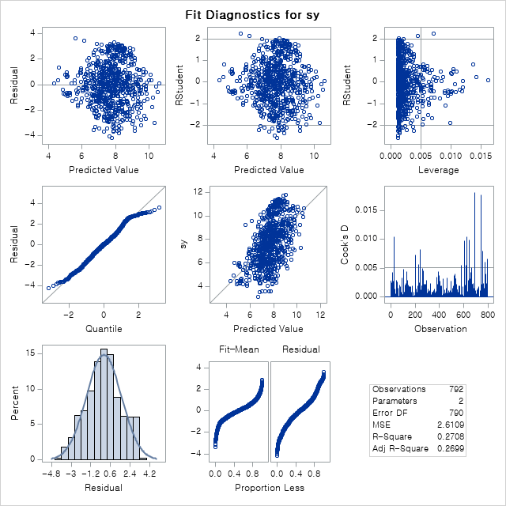

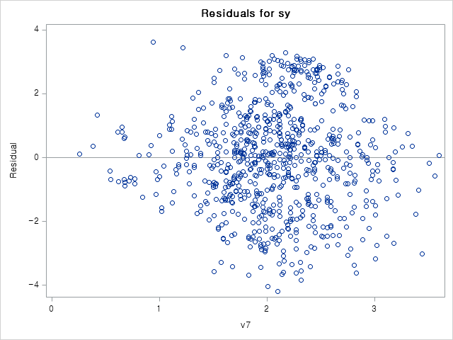

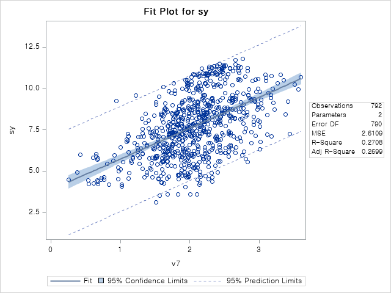

The REG Procedure

Model: MODEL2

Dependent Variable: sy

| Number of Observations Read | 792 |
| --- | --- |
| Number of Observations Used | 792 |

| Analysis of Variance Source | Analysis of Variance DF | Analysis of Variance Sum of Squares | Analysis of Variance Mean Square | Analysis of Variance F Value | Analysis of Variance Pr > F |
| --- | --- | --- | --- | --- | --- |
| Model | 2 | 769.17515 | 384.58758 | 147.34 | <.0001 |
| Error | 789 | 2059.44709 | 2.61020 |  |  |
| Corrected Total | 791 | 2828.62224 |  |  |  |

| Root MSE | 1.61561 | R-Square | 0.2719 |
| --- | --- | --- | --- |
| Dependent Mean | 7.72892 | Adj R-Sq | 0.2701 |
| Coeff Var | 20.90346 |  |  |

| Parameter Estimates Variable | Parameter Estimates DF | Parameter Estimates Parameter Estimate | Parameter Estimates Standard Error | Parameter Estimates t Value | Parameter Estimates Pr > \|t\| |
| --- | --- | --- | --- | --- | --- |
| Intercept | 1 | 2.92489 | 0.87593 | 3.34 | 0.0009 |
| v7 | 1 | 2.70911 | 0.76600 | 3.54 | 0.0004 |
| vlnv7 | 1 | -0.50839 | 0.45963 | -1.11 | 0.2690 |

The REG Procedure

Model: MODEL2

Dependent Variable: sy

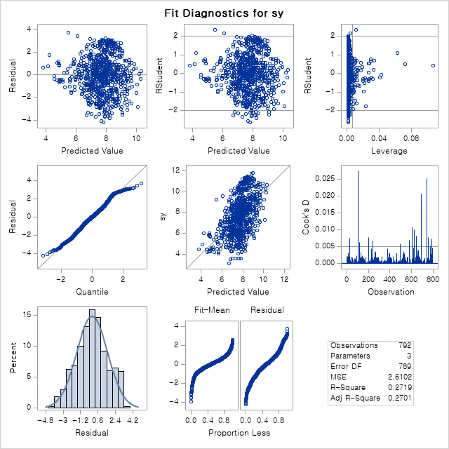

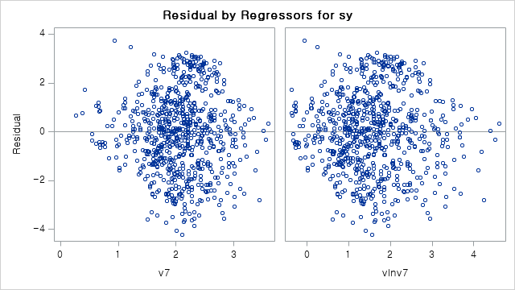

The REG Procedure

Model: MODEL1

Dependent Variable: sy

| Number of Observations Read | 792 |
| --- | --- |
| Number of Observations Used | 792 |

| Analysis of Variance Source | Analysis of Variance DF | Analysis of Variance Sum of Squares | Analysis of Variance Mean Square | Analysis of Variance F Value | Analysis of Variance Pr > F |
| --- | --- | --- | --- | --- | --- |
| Model | 1 | 1387.83047 | 1387.83047 | 760.96 | <.0001 |
| Error | 790 | 1440.79177 | 1.82379 |  |  |
| Corrected Total | 791 | 2828.62224 |  |  |  |

| Root MSE | 1.35048 | R-Square | 0.4906 |
| --- | --- | --- | --- |
| Dependent Mean | 7.72892 | Adj R-Sq | 0.4900 |
| Coeff Var | 17.47304 |  |  |

| Parameter Estimates Variable | Parameter Estimates DF | Parameter Estimates Parameter Estimate | Parameter Estimates Standard Error | Parameter Estimates t Value | Parameter Estimates Pr > \|t\| |
| --- | --- | --- | --- | --- | --- |
| Intercept | 1 | 4.71926 | 0.11919 | 39.59 | <.0001 |
| v0 | 1 | 0.06790 | 0.00246 | 27.59 | <.0001 |

The REG Procedure

Model: MODEL1

Dependent Variable: sy

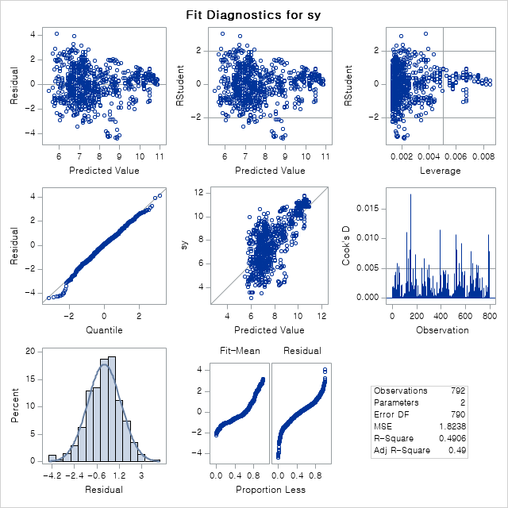

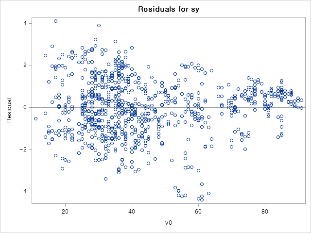

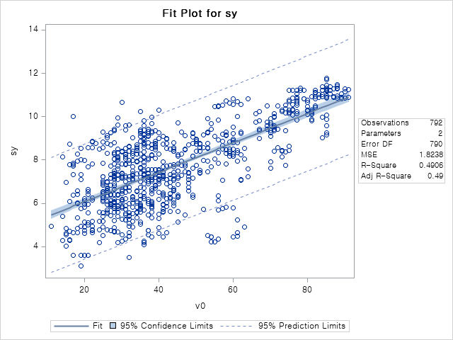

The REG Procedure

Model: MODEL2

Dependent Variable: sy

| Number of Observations Read | 792 |
| --- | --- |
| Number of Observations Used | 792 |

| Analysis of Variance Source | Analysis of Variance DF | Analysis of Variance Sum of Squares | Analysis of Variance Mean Square | Analysis of Variance F Value | Analysis of Variance Pr > F |
| --- | --- | --- | --- | --- | --- |
| Model | 2 | 1411.92462 | 705.96231 | 393.17 | <.0001 |
| Error | 789 | 1416.69762 | 1.79556 |  |  |
| Corrected Total | 791 | 2828.62224 |  |  |  |

| Root MSE | 1.33999 | R-Square | 0.4992 |
| --- | --- | --- | --- |
| Dependent Mean | 7.72892 | Adj R-Sq | 0.4979 |
| Coeff Var | 17.33730 |  |  |

| Parameter Estimates Variable | Parameter Estimates DF | Parameter Estimates Parameter Estimate | Parameter Estimates Standard Error | Parameter Estimates t Value | Parameter Estimates Pr > \|t\| |
| --- | --- | --- | --- | --- | --- |
| Intercept | 1 | 6.64373 | 0.53850 | 12.34 | <.0001 |
| v0 | 1 | -0.14265 | 0.05753 | -2.48 | 0.0134 |
| vlnv0 | 1 | 0.04303 | 0.01175 | 3.66 | 0.0003 |

The REG Procedure

Model: MODEL2

Dependent Variable: sy

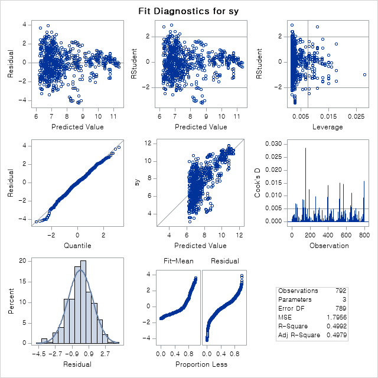

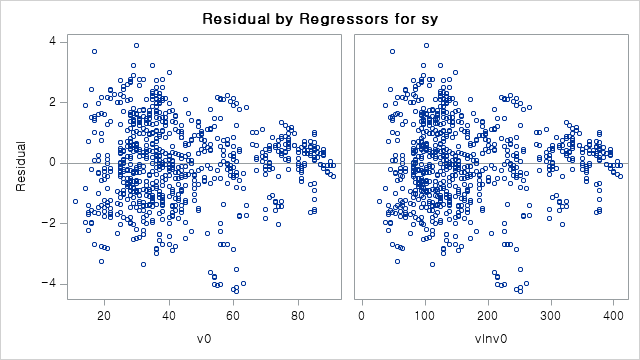